# Final_Project

### Motivation

The goal of this project is to track COVID-19 spread across countries. The general information is of little use to people if they don't have information pertaining to their cities, states or counties. We are going to be diving deep to explore COVID-19 spread and measures in the United States of America.

### Data Exploration

The data is gathered from the GitHub repository of Johns Hopkins University. It provides a time series data of the counts of confirmed cases of COVID-19 in the United States of America. Below we load the necessary packages and view the first few rows of our data set to get a feel of the variables we are dealing with.

```python
import pandas as pd
import numpy as np
from datetime import datetime
import matplotlib as mpl
import matplotlib.pyplot as plt
%matplotlib inline
import seaborn as sns
import plotly
import plotly.graph_objects as go


mpl.rcParams['figure.figsize'] = (16, 9)
sns.set(style="darkgrid")

import dash
import dash_core_components as doc
import dash_html_components as html
from dash.dependencies import Input, Output
from sklearn import linear_model
from sklearn.metrics import mean_absolute_error

from sklearn.preprocessing import PolynomialFeatures
from sklearn.pipeline import make_pipeline

data_raw = pd.read_csv("data_raw.csv")
```

```python
from IPython.display import HTML

HTML('''<script>
code_show=true;
function code_toggle() {
 if (code_show){
 $('div.input').hide();
 } else {
 $('div.input').show();
 }
 code_show = !code_show
}
$( document ).ready(code_toggle);
</script>
<form action="javascript:code_toggle()"><input type="submit" value="Click here to toggle on/off the raw code."></form>''')
```

```python
#data_raw.head()
```

There are a lot of different data types stored in our data set. We have strings pertaining to region information, geolocation variables and numerical variables. This, if we think in terms of relational database and warehousing, is a very poor techinique. So, we are going to subset our data sets based on the type of variables they store.

```python
time_index = data_raw.columns[11:]
```

Now we create a new vector of the dates in listed in our columns.

```python
plot_df = pd.DataFrame({'date': time_index})
#analysis_data.head()
```

We won't focus our analysis on the entiriety of the United States. Below we check out the different states that are included in our data set and then choose a few select states to focus our analyses on.

```python
#data_raw['Province_State'].unique()
```

Below, we take New York, as an example, to show how we are going to work with the data we have. We are going to sum up the values in the columns for the different dates. So that the resultant dataframe would be a key value pair of the date in question and the total number of confirmed cases in New York until that day.

```python
data_raw[data_raw['Province_State'] == 'New York'].iloc[:, 11::].sum(axis=0)
```

```
1/22/20         0
1/23/20         0
1/24/20         0
1/25/20         0
1/26/20         0
            ...
4/18/20    241712
4/19/20    247815
4/20/20    253060
4/21/20    258361
4/22/20    263292
Length: 92, dtype: int64
```

We are going to be focusing on a few more regions/states as well. The states/provinces we are going to be focusing on are California, New York, Texas, Washington, Illinois, Massachusetts, Florida, Pennsylvania, District of Columbia and Colorado.

```python
list_of_states = ["California", "New York", "Texas", "Washington", "Illinois", "Massachusetts", "Florida", "Pennsylvania", "District of Columbia", "Colorado"]

for state in list_of_states:
    plot_df[state] = np.array(data_raw[data_raw['Province_State'] == state].iloc[:, 11::].sum(axis=0))
```

What we end up with below is a table with each date listed as a row and the columns contain the total number of confirmed COVID-19 cases for the different states that day.

```python
plot_df['Florida'][35:]
```

```
35        0
36        0
37        0
38        0
39        0
40        1
41        2
42        2
43        3
44        3
45        7
46       10
47       13
48       15
49       24
```

[output cut: 43 more lines]

If we look at the graph for Florida closely, we can see that Florida doesn't encounter its first COVID-19 case until the first week of March. Within a month, this figure rises up to 6956. I might just be speculating but the onset of Spring Break has led to a sharp increase in the total number of confirmed cases of COVID-19 in Florida.

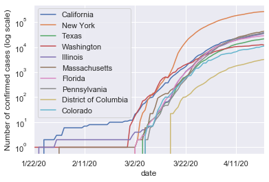

```python
plt.figure()
ax = plot_df.set_index('date').plot()
ax.set_yscale('log')
#ax.title("Number of confirmed COVID-19 cases across selected states over time")
ax.set_ylabel("Number of confirmed cases (log scale)")
```

Our dates are stored as strings which can be tricky as we cannot perform date/time operations on strings. First, we have to convert them into a date/time object.

```python
time_idx = [datetime.strptime(time, "%m/%d/%y") for time in plot_df.date]
#time_idx
```

### Subsetting the dataset

In our original dataset, we have both transactional data and static data. Transactional data like dates are dynamic, they descirbe attributes at a given time and are subject to change. The longitude and latitude values are static column values. Their values remain the same over time. We are going to separate our static data from the transactional data and set our primary key for the new relation. Our primary key is set to the `Combined_Key` attribute.

```python
#Setting `Combined_Key` as the primary key and Transposing the resulting dataframe.
new_df = data_raw.drop(["UID", "iso2", "iso3", "code3", "FIPS", "Admin2", "Province_State", "Country_Region", "Lat", "Long_"], axis = 1).set_index('Combined_Key').T
#new_df.head()
```

```python
#Stacking the multi-level inidex into a single attribute and renaming the columns.
ndf = new_df.stack(level = 0).reset_index().rename(columns={'level_0': 'Date', 0: 'Confirmed_Cases'})
#ndf.head()
```

```python
ndf['Date'] = ndf.Date.astype('datetime64[ns]')
#ndf.dtypes
```

#### Plotly for interactive visualization

The time series chart from below can be turned into an interactive chart using Plotly. The interactive chart has a slider for the range of date values for which the chart adjust accordingly.

```python
fig = go.Figure()

for each in list_of_states:
    fig.add_trace(go.Scatter(x = plot_df.date.astype('str'), y = plot_df[each], mode = 'markers+lines', opacity = 0.9, name = each))

fig.update_layout(width = 1000, height = 600, xaxis_title = "Date", yaxis_title = "Number of Confirmed Cases, log scale", title = "Time Series of Confirmed COVID-19 Cases")
fig.update_yaxes(type = "log", range = [1.5, 5.5])

fig.update_layout(xaxis_rangeslider_visible = True)
```

[interactive chart not shown]

```python
#app = dash.Dash()
#app.layout = html.Div([
#    html.Label("Select Countries"),
#    doc.Dropdown(
#        id='drop_down_country',
#        options = [
#            {'label': 'California', 'value': 'California'},
#            {'label': 'New York', 'value': 'New York'},
#            {'label': 'Texas', 'value': 'Texas'},
#            {'label': 'Washington', 'value': 'Washington'},
#            {'label': 'Illinois', 'value': 'Illinois'},
#            {'label': 'Massachusetts', 'value': 'Massachusetts'},
#           {'label': 'Florida', 'value': 'Florida'},
#           {'label': 'Pennsylvania', 'value': 'Pennsylvania'},
#           {'label': 'District of Columbia', 'value': 'District of Columbia'},
#            {'label': 'Colorado', 'value': 'Colorado'}],
#        value = ["New York", "California"],
#        multi = True
#    ),
#
#    doc.Graph(figure = fig, id = 'main_window_slope')
#])
```

```python
#app.run_server(debug = True, use_reloader = False)
```

```python
#@app.callback(
#    Output('main_window_slope', 'figure'),
#    [Input("drop_down_country", 'value')])
#def figure_update(list_of_states):
#    traces = []
#   for each in list_of_states:
#        traces.append(dict(x = plot_df.date, y = plot_df[each], mode = 'markers+lines', opacity = 0.9, name = each))
#
#    return {
#            'data': traces,
#            'layout': dict(
#                width = 1000,
#                height = 600,
#                yaxis_title = "Confirmed cases of Infection(log scale)",
#                xaxis_title = "Time"
#            )
#    }
```

### Trying to model COVID-19 Spread

I would just like to reiterate that this section only attempts at modelling the spread of COVID-19. During this process, we are going to highlight the key aspects of why modelling infectious diseases like this is complex and often fails. There have been a lot of graphs and analyses posted on the internet regarding COVID-19. However, most of them fail to recognize the limitations of their data source and the effect of latent variables in their model.

A quick reminder of how our time series data looked.

```python
analysis_data = plot_df
#analysis_data
```

```python
def easy_plot(inp, df_inp, y_scale = 'log', slider = False):
    fig = go.Figure()

    for value in df_inp.columns:
        fig.add_trace(go.Scatter(x = inp, y = df_inp[value], name = value, opacity = 0.9))

    fig.update_layout(autosize = True,
                     width = 900,
                     height = 600,
                     font = dict(
                         family="PT Sans, monospace",
                         size = 16,
                         color = "#7f7f7f"
                         )
                     )

    fig.update_yaxes(type = 'log')
    fig.update_xaxes(nticks = 20, tickangle = -45)

    if slider == True:
        fig.update_layout(xaxis_rangeslider_visible = True)
    fig.show()
```

```python
easy_plot(plot_df.date, plot_df.iloc[:, 1:11], y_scale = 'log', slider = True)
```

[interactive chart not shown]

Let us see if we can predict the number of confirmed cases in New York, using Ordinary Least Squares regression. The scikit learn package provides us with a linear model object for all our linear regression needs. The features contain a matrix of attributes that help us predict the target, which is a column of the daily total number of confirmed cases in New York.

```python
ols = linear_model.LinearRegression()

vector_length = len(analysis_data['New York'])

features = np.arange(vector_length).reshape(-1, 1)
target = np.array(analysis_data['New York'])
```

```python
ols.fit(features, target)
```

```
LinearRegression(copy_X=True, fit_intercept=True, n_jobs=None, normalize=False)
```

```python
X_hat = np.arange(vector_length).reshape(-1, 1)
Y_hat = ols.predict(X_hat)

ols.fit(features, target)
```

```
LinearRegression(copy_X=True, fit_intercept=True, n_jobs=None, normalize=False)
```

```python
ols_inspect = analysis_data[['date', 'New York']].copy()
ols_inspect['prediction'] = Y_hat
```

```python
easy_plot(ols_inspect.date,
         ols_inspect.iloc[:, 1:],
         slider = True)
```

[interactive chart not shown]

```python
vector_length_exp = len(analysis_data['California']) - 5

features_exp = np.arange(vector_length_exp).reshape(-1, 1)
target_exp = np.log(np.array(analysis_data['California'][5:]))

ols.fit(features_exp, target_exp)

X_hat_exp = np.arange(vector_length).reshape(-1, 1)
Y_hat_exp = ols.predict(X_hat_exp)


ols_inspect_exp = analysis_data[['date', 'California']].copy()
ols_inspect_exp['prediction'] = np.exp(Y_hat_exp)

easy_plot(ols_inspect_exp.date,
          ols_inspect_exp.iloc[:, 1:],
          slider = True)
```

[interactive chart not shown]

### Piecewise linear approximation for New York COVID-19 data

We would like to look at the doubling rate of confirmed cases in New York. Doubling rate defines the time taken for the current number of confirmed cases to double. A doubling rate of 2 indicates that the current number of confirmed cases will take 2 days to double and a doubling rate of 15 implies that the current number of confirmed cases will double in 15 days.

In this section, we are going to see how we can derive the doubling rate for COVID-19 in New York using Piecewise Linear Regression approximation of the intercept and the slope for our data. The doubling rate is defined as the ratio of the intercept of the piecewise linear regression to the slope of the piecewise linear regression.

Later we are going to compare this against the doubling rate derived from the formal mathematical formula.

```python
len_vector = len(analysis_data['New York'])
X = np.arange(len_vector - 40).reshape(-1, 1)
y= np.array(analysis_data['New York'][40:])

piecewise_regression = linear_model.LinearRegression(fit_intercept = True)

piecewise_regression.fit(X, y)
```

```
LinearRegression(copy_X=True, fit_intercept=True, n_jobs=None, normalize=False)
```

```python
piecewise_regression.intercept_
```

```
-61041.158925979646
```

```python
piecewise_regression.coef_
```

```
array([5742.02885683])
```

```python
piecewise_regression.coef_/piecewise_regression.intercept_
```

```
array([-0.09406815])
```

```python
def get_doubling_rate(array_in):
    y = np.array(array_in)
    X = np.arange(-1, 2).reshape(-1, 1)

    assert len(array_in) == 3

    piecewise_regression.fit(X, y)
    intercept = piecewise_regression.intercept_
    slope = piecewise_regression.coef_
    return intercept/slope
```

```python
for each in list_of_states:
    analysis_data[each + ' Doubling Rate'] = analysis_data[each].rolling(window = 3, min_periods = 3).apply(get_doubling_rate)
```

[output not shown]

```python
easy_plot(analysis_data.date, analysis_data.iloc[40:, [11]], y_scale = 'linear')
```

[interactive chart not shown]

### Checking to see if our linear approximation of Doubling Rate follows the value given by the formal mathematical definition of doubling rate

```python
def doubling_rate(array_in):
    y = np.array(array_in)
    return len(y)*np.log(2)/np.log(y[-1]/y[0])
```

```python
analysis_data['New York Doubling Rate Actual'] = analysis_data['New York'].rolling(window = 3, min_periods = 3).apply(doubling_rate)
```

```python
#easy_plot(analysis_data.date, analysis_data.iloc[40:, [11, 12]], y_scale = 'linear')
analysis_data
```

|  | date | California | New York | Texas | Washington | Illinois | Massachusetts | Florida | Pennsylvania | District of Columbia | ... | New York Doubling Rate | Texas Doubling Rate | Washington Doubling Rate | Illinois Doubling Rate | Massachusetts Doubling Rate | Florida Doubling Rate | Pennsylvania Doubling Rate | District of Columbia Doubling Rate | Colorado Doubling Rate | New York Doubling Rate Actual |
| --- | --- | --- | --- | --- | --- | --- | --- | --- | --- | --- | --- | --- | --- | --- | --- | --- | --- | --- | --- | --- | --- |
| 0 | 1/22/20 | 0 | 0 | 0 | 1 | 0 | 0 | 0 | 0 | 0 | ... | NaN | NaN | NaN | NaN | NaN | NaN | NaN | NaN | NaN | NaN |
| 1 | 1/23/20 | 0 | 0 | 0 | 1 | 0 | 0 | 0 | 0 | 0 | ... | NaN | NaN | NaN | NaN | NaN | NaN | NaN | NaN | NaN | NaN |
| 2 | 1/24/20 | 0 | 0 | 0 | 1 | 1 | 0 | 0 | 0 | 0 | ... | NaN | NaN | inf | 0.666667 | NaN | NaN | NaN | NaN | NaN | NaN |
| 3 | 1/25/20 | 0 | 0 | 0 | 1 | 1 | 0 | 0 | 0 | 0 | ... | NaN | NaN | inf | 1.333333 | NaN | NaN | NaN | NaN | NaN | NaN |
| 4 | 1/26/20 | 2 | 0 | 0 | 1 | 1 | 0 | 0 | 0 | 0 | ... | NaN | NaN | inf | inf | NaN | NaN | NaN | NaN | NaN | NaN |
| ... | ... | ... | ... | ... | ... | ... | ... | ... | ... | ... | ... | ... | ... | ... | ... | ... | ... | ... | ... | ... | ... |
| 87 | 4/18/20 | 30491 | 241712 | 18704 | 11776 | 29160 | 36372 | 25492 | 31652 | 2666 | ... | 25.747739 | 19.485412 | 31.849791 | 16.048258 | 16.377157 | 22.830464 | 17.638578 | 15.805907 | 22.798073 | 26.837980 |
| 88 | 4/19/20 | 31431 | 247815 | 19260 | 11978 | 30357 | 38077 | 26314 | 32902 | 2793 | ... | 27.882603 | 26.370423 | 51.006508 | 20.893607 | 19.746213 | 32.825295 | 20.889626 | 16.687697 | 17.624639 | 28.876760 |
| 89 | 4/20/20 | 33686 | 253060 | 19751 | 12114 | 31513 | 38077 | 27059 | 33914 | 2927 | ... | 43.625132 | 36.749443 | 70.745562 | 25.791189 | 43.998436 | 33.552436 | 29.020925 | 21.420179 | 27.825281 | 45.323802 |
| 90 | 4/21/20 | 35465 | 258361 | 20574 | 12563 | 33059 | 41199 | 27869 | 35249 | 3098 | ... | 47.995196 | 30.230847 | 41.772080 | 23.421910 | 25.059364 | 34.830439 | 28.991621 | 19.274317 | 26.857784 | 49.896221 |
| 91 | 4/22/20 | 37344 | 263292 | 21321 | 12051 | 35107 | 42944 | 28309 | 36082 | 3206 | ... | 50.476479 | 26.176645 | -388.656085 | 18.489891 | 16.741319 | 44.393067 | 32.363161 | 22.057348 | 17.854723 | 52.462043 |

92 rows × 22 columns

#### Fitting a polynomial curve to COVID-19 confirmed cases for the selected states

```python
polynomial_df = analysis_data.iloc[54:, 0:11].reset_index()
```

```python
def Poly_Reg(degree = 2, **kwargs):
    return make_pipeline(PolynomialFeatures(degree), linear_model.LinearRegression(**kwargs))
```

```python
y = polynomial_df[['New York', 'New York',  'Washington', 'Florida', 'California' ]].unstack().sort_index(axis = 0, level = 1)

test_points = 38
y_train = y[0:-test_points - 1]
y_test = y[-test_points:]
```

```python
X_test = np.arange(len(y_train), len(y_train) + test_points).reshape(-1, 1) / 5.0
X_train = np.arange(len(y_train)).reshape(-1, 1) / 5.0
```

```python
def mean_absolute_percent_error(y_true, y_pred):
    y_true, y_pred = np.array(y_true), np.array(y_pred)
    return np.mean(np.abs((y_true - y_pred) / y_true)) * 100
```

We set the degree of our polynomial model to see how it affects our predictions. We can see that for different degrees the prediction lines start out far away from each other, then converge towards the center of the graph and then diverge towards the tails again. The degree for our polynomial model should be 2 as we acheive a lower mean absolute percent in our test data set error for this model compared to the original model.

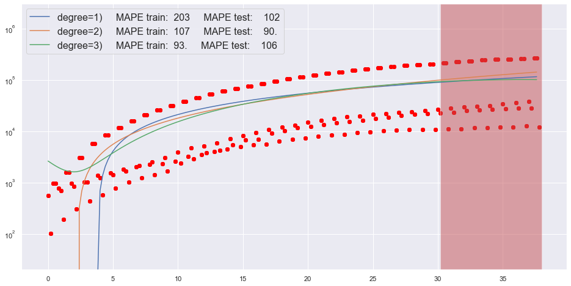

```python
sns.set(rc={"figure.figsize":(16, 8)})

fig, ax = plt.subplots(1, 1)

for degree in [1, 2, 3]:
    insample_y_hat = Poly_Reg(degree).fit(X_train, y_train).predict(X_train)
    y_hat_test = Poly_Reg(degree).fit(X_train, y_train).predict(X_test)

    X_plot = np.concatenate((X_train, X_test), axis = None)
    y_plot = np.concatenate((insample_y_hat, y_hat_test), axis = None)

    ax.scatter(np.arange(len(y)) / 5, y, color = 'red')
    ax.axvspan((len(y) - test_points - 1) / 5, len(y) / 5, facecolor = 'r', alpha = 0.2)

    ax.plot(X_plot, y_plot, label = 'degree={0})'.format(degree) +
            '     MAPE train:  ' + str(mean_absolute_percent_error(insample_y_hat, y_train))[0:3]
            + '     MAPE test:    ' + str(mean_absolute_percent_error(y_hat_test, y_test))[0:3])


ax.set_yscale('log')
ax.set_ylim(20, 3000000)
ax.legend(loc = "best", prop = {'size': 16})
```

#### SIR modelling of COVID-19

One of the easiest ways to model them is with a compartmental model. A compartmental model separates the population into several compartments.

- Susceptible, people that are healthy but can still be infected
- Infected, people who have the virus
- Recovered, were previously infected but can no longer get the infection

We have a few parameters that we have to define for our model. They are:

- $\beta$ : The number of people an infected person infects
- $\gamma$ : The number of infected people that are recovering each day

Based on these parameters we can create an SIR model for our COVID-19 data set.

```python
def SIR_model(SIR, beta, gamma):
    S,I,R = SIR
    dS_dt = -beta * S * I / N0
    dI_dt = beta * S * I / N0 - gamma * I
    dR_dt = gamma * I
    return([dS_dt, dI_dt, dR_dt])
```

```python
N0 = 1000000 #19795791
beta = 0.4
gamma = 0.1

I0 = analysis_data.California[41]
S0 = N0 - I0
R0 = 0
```

```python
SIR = np.array([S0, I0, R0])
prop_rate = pd.DataFrame(columns = {"susceptible": S0, "infected": I0, "recovered": R0})

for each in np.arange(100):
    new_delta = SIR_model(SIR, beta, gamma)
    SIR = SIR + new_delta
    prop_rate = prop_rate.append({"susceptible": SIR[0], "infected": SIR[1], "recovered": SIR[2]}, ignore_index = True)
```

A demonstration of what an SIR model looks visually is given below. Please note that this not an actual representation of how COVID-19 modelling works. We have to realize that our parameters $\beta$ and $\gamma$ change over time continuously. The erratic nature of it's fluctuation is what makes our model complex to build.

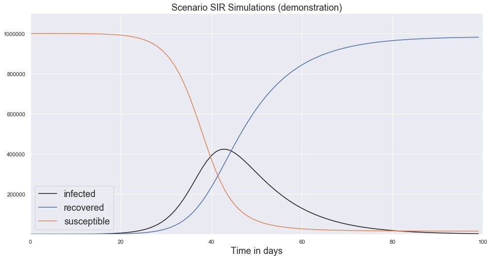

```python
fig, ax = plt.subplots(1, 1)

prop_rate_plot = prop_rate #.iloc[35:, :]
ax.plot(prop_rate_plot.index, prop_rate_plot.infected, label = "infected", color = "k")
ax.plot(prop_rate_plot.index, prop_rate_plot.recovered, label = "recovered")
ax.plot(prop_rate_plot.index, prop_rate_plot.susceptible, label = "susceptible")

ax.set_ylim(10, 1100000)
ax.set_xlim(0, 100)
ax.set_yscale('linear')
ax.set_title("Scenario SIR Simulations (demonstration)", size = 18)
ax.set_xlabel('Time in days', size = 18)
ax.legend(loc = 'best', prop = {'size': 18})
```

For the next part of this project, we merge the data set we have global confirmed cases with the data set from the World Health Organization regarding the health infrastructure of different countries around the globe. We are going to filter out information pertaining to number of smokers, hospital beds and other metrics for the quality of health in different countries.

The visualization have been turned into a Tableau Dashboard and is available via the following link: [COVID-19 Dashboard](https://public.tableau.com/profile/amulya.pandey#!/vizhome/COVID-19DATADASHBOARD/Dashboard1?publish=yes)